# Reproducibility Report

# Report Details

```r
articleID <- "6-1-2015"
reportType <- "pilot"
pilotNames <- "Ayo Dada"
copilotNames <- "Effie Li"
pilotTTC <- 180
copilotTTC <- 120
pilotStartDate <- as.Date("11/8/19", format = "%m/%d/%y")
copilotStartDate <- as.Date("11/9/19", format = "%m/%d/%y")
completionDate <- as.Date("11/10/19", format = "%m/%d/%y")
```

#### Methods summary:

Experiment 1 was conducted with 10 participants (5 females, 5 males) who were exposed to some perceptual tasks in a within-subjects design. Participants were exposed to two types of stimuli which were white disks of either 3 cm or 3.75 cm. They were required to either grasp the disk or estimate its size manually in both disk size conditions. Participants were also made to perform the task when the disk was isolated or when the disk was crowded with distracters. Sometimes, the participants would be able to see the hand movements they were making toward the disks for a period of 3 seconds (closed loop) and at other times they were totally blind to their own hand movements (open loop). This visual condition was achieved with a pair of specialized goggles for this experiment. When all the conditions were taken together, this yielded a 4 way (2x2x2x2) repeated measures design in which each participant was subjected to every variation of the experimental procedure.

#### Target outcomes:

## Experiment 1 was designed to explore the effects of crowding on perception and action, with a particular focus on whether participants could scale their grip aperture to the size of the target even when they could not consciously identify the size of the target. We carried out a four-way repeated measures ANOVA on the manual estimates and PGAs with task (estimation vs. grasping), crowding condition (uncrowded vs. crowded), viewing condition (closed- vs. open-loop), and target size (3.0 vs. 3.75 cm) as main factors. The significant interaction between task and crowding condition, F(1, 9) = 6.818, p = .028, suggested that crowding had different effects on performance of the grasping and manual estimation tasks. Not surprisingly, when the target was presented in isolation, participants were able to manually estimate the sizes of the two targets—and this was true for both closed-loop trials, t(9) = 7.23, p < .001, and open-loop trials, t(9) = 9.19, p < .001. Similarly, participants showed excellent grip scaling for targets presented in isolation on both closed-loop trials, t(9) = 4.29, p = .002, and openloop trials, t(9) = 4.79, p = .001 . Things were quite different, however, when the target disks were surrounded by flankers. In this condition, participants could no longer discriminate between the two disk sizes using a manual estimate closed-loop trials: t(9) = 1.02, p = .334; open-loop trials: t(9) = 1.78, p = .108?presumably because the size of the target was perceptually invisible. (Note that we use the term invisible to refer to the fact that participants could not identify the size of the target, even though they were aware of its presence and position.) In contrast, when participants were asked to grasp the same targets, their PGAs were still scaled to target size?closed-loop trials: t(9) = 4.21, p = .002; open-loop trials: t(9) = 3.392, p = .008.

# Step 1: Load packages and prepare report object

```r
# load packages
library(tidyverse) # for data munging
library(knitr) # for kable table formating
library(haven) # import and export 'SPSS', 'Stata' and 'SAS' Files
library(readxl) # import excel files
library(ReproReports) # custom reporting functions
library(lsr) # the aov function that runs ANOVA
```

[PILOT/COPILOT DO NOT MAKE CHANGES TO THE CODE CHUNK BELOW]

```r
# Prepare report object. This will be updated automatically by the reproCheck function each time values are compared
reportObject <- data.frame(dummyRow = TRUE, reportedValue = NA, obtainedValue = NA, valueType = NA, percentageError = NA, comparisonOutcome = NA, eyeballCheck = NA)
```

# Step 2: Load data

```r
CrowdPercep <- read_xlsx("data/data_Exp1.xlsx", sheet = "summary")
```

# Step 3: Tidy data

```r
CrowdPercep <- CrowdPercep[,-c(1,6,11,16)] # This removes those columns with NA all through

# Next, we rename the columns to match the different conditions in the experiment. For those columns which already had a name, we simply change the names. For those without names, we use their index or position to assign names to them

colnames(CrowdPercep)[colnames(CrowdPercep)=="closed-loop grasping"] <- "closed_grasp_uncr_3cm"

names(CrowdPercep)[2]<-"closed_grasp_uncr_3.75cm"

names(CrowdPercep)[3]<-"closed_grasp_cr_3cm"

names(CrowdPercep)[4]<-"closed_grasp_cr_3.75cm"

colnames(CrowdPercep)[colnames(CrowdPercep)=="open-loop_grasping"] <- "open_grasp_uncr_3cm"

names(CrowdPercep)[6]<-"open_grasp_uncr_3.75cm"

names(CrowdPercep)[7]<-"open_grasp_cr_3cm"

names(CrowdPercep)[8]<-"open_grasp_cr_3.75cm"

colnames(CrowdPercep)[colnames(CrowdPercep)=="closed-loop estimation"] <- "closed_estim_uncr_3cm"

names(CrowdPercep)[10]<-"closed_estim_uncr_3.75cm"

names(CrowdPercep)[11]<-"closed_estim_cr_3cm"

names(CrowdPercep)[12]<-"closed_estim_cr_3.75cm"


colnames(CrowdPercep)[colnames(CrowdPercep)=="open-loop estimation"] <- "open_estim_uncr_3cm"

names(CrowdPercep)[14]<-"open_estim_uncr_3.75cm"

names(CrowdPercep)[15]<-"open_estim_cr_3cm"

names(CrowdPercep)[16]<-"open_estim_cr_3.75cm"


CrowdPercep <- CrowdPercep[-c(1,2,13),] # We can now take out the top two rows which had some header information and the bottom row which already had some computed means

CrowdPercep$SubjectID <- 1:10 # We need to run a repeated-measures anova, so a column of SubjectID will help

# Here we convert the data to long data with each row representing a single observation
CrowdPercep_long <- CrowdPercep %>%
  pivot_longer(cols = `closed_grasp_uncr_3cm`:`open_estim_cr_3.75cm`, names_to = c("ViewingLoop", "Task", "CrowdingCond", "TargetSize"), names_sep = "_", values_to = "Measure")
```

# Step 4: Run analysis

## Pre-processing

```r
# In order to run any analyses, we need to have the measure data in numeric form

CrowdPercep_long$Measure <- as.numeric(as.character(CrowdPercep_long$Measure))

# We could also have the conditions as factors
CrowdPercep_long$SubjectID<- as.factor(CrowdPercep_long$SubjectID)
CrowdPercep_long$ViewingLoop <- as.factor(as.character(CrowdPercep_long$ViewingLoop))
CrowdPercep_long$Task <- as.factor(as.character(CrowdPercep_long$Task))
CrowdPercep_long$CrowdingCond <- as.factor(as.character(CrowdPercep_long$CrowdingCond))
CrowdPercep_long$TargetSize <- as.factor(as.character(CrowdPercep_long$TargetSize))

# It may also be useful to see the difference between the object and the perceptions of the participants in all observations

CrowdPercep_long <- CrowdPercep_long %>%
  mutate(Delta = ifelse(TargetSize == "3cm", Measure - 3, Measure - 3.75 ))
```

## Descriptive statistics

```r
# This computes the means of the dataset
Descriptives <- CrowdPercep_long %>%
  group_by(ViewingLoop, Task, CrowdingCond, TargetSize)%>%
  summarise(mean(Measure))
```

## Inferential statistics

```r
# 4-way repeated-measures ANOVA

model = aov(Measure ~ ViewingLoop * Task * CrowdingCond * TargetSize + Error(SubjectID/(ViewingLoop * Task * CrowdingCond * TargetSize)), data=CrowdPercep_long)
summary(model)$"Error: SubjectID:Task:CrowdingCond"
```

```
##                   Df Sum Sq Mean Sq F value Pr(>F)
## Task:CrowdingCond  1  1.554  1.5540   6.818 0.0282 *
## Residuals          9  2.051  0.2279
## ---
## Signif. codes:  0 '***' 0.001 '**' 0.01 '*' 0.05 '.' 0.1 ' ' 1
```

```r
# check values
reportObject <- reproCheck(reportedValue = '1', obtainedValue = '1', valueType = 'df')
```

```
## [1] "MATCH for df. The reported value (1) and the obtained value (1) differed by 0%. Note that the obtained value was rounded to 0 decimal places to match the reported value."
```

```r
reportObject <- reproCheck(reportedValue = '9', obtainedValue = '9', valueType = 'df')
```

```
## [1] "MATCH for df. The reported value (9) and the obtained value (9) differed by 0%. Note that the obtained value was rounded to 0 decimal places to match the reported value."
```

```r
reportObject <- reproCheck(reportedValue = '6.818', obtainedValue = '6.818', valueType = 'F')
```

```
## [1] "MATCH for F. The reported value (6.818) and the obtained value (6.818) differed by 0%. Note that the obtained value was rounded to 3 decimal places to match the reported value."
```

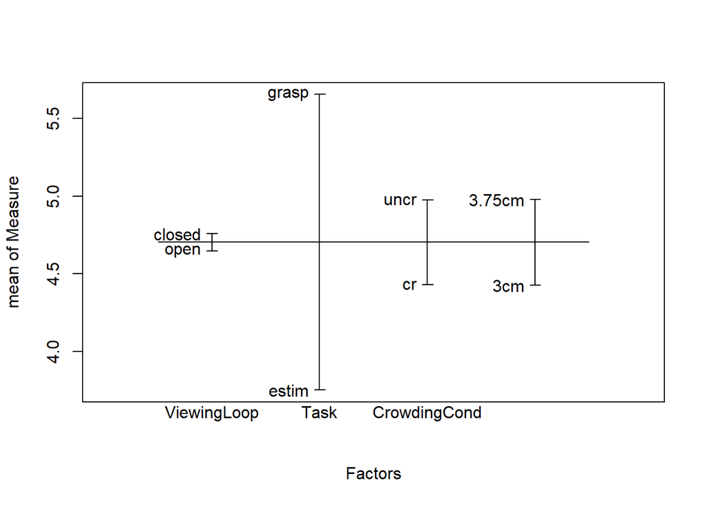

```r
plot.design(Measure ~ ViewingLoop * Task * CrowdingCond * TargetSize, data=CrowdPercep_long)
```

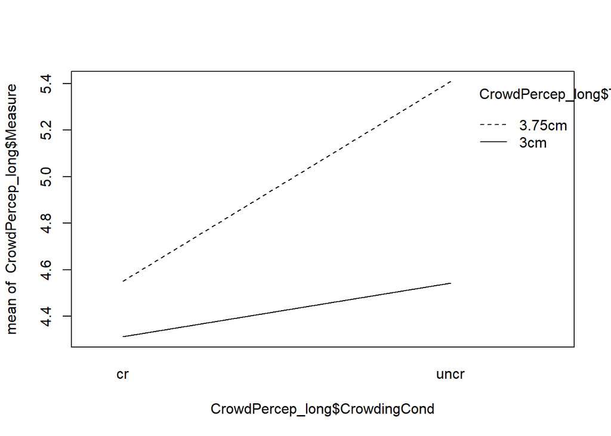

```r
interaction.plot(CrowdPercep_long$CrowdingCond, CrowdPercep_long$TargetSize, CrowdPercep_long$Measure)
```

```r
"The significant interaction between task and crowding condition, F(1, 9) = 6.818, p = .028..."
```

```
## [1] "The significant interaction between task and crowding condition, F(1, 9) = 6.818, p = .028..."
```

```r
# Pairwise t-tests

"...when the target was presented in isolation, participants were able to manually estimate the sizes of the two targets—and this was true for both closed-loop trials, t(9) = 7.23, p < .001, ..."
```

```
## [1] "...when the target was presented in isolation, participants were able to manually estimate the sizes of the two targets—and this was true for both closed-loop trials, t(9) = 7.23, p < .001, ..."
```

```r
t.test(as.numeric(CrowdPercep$closed_estim_uncr_3.75cm), as.numeric(CrowdPercep$closed_estim_uncr_3cm), paired = TRUE)
```

```
##
##  Paired t-test
##
## data:  as.numeric(CrowdPercep$closed_estim_uncr_3.75cm) and as.numeric(CrowdPercep$closed_estim_uncr_3cm)
## t = 7.2342, df = 9, p-value = 4.899e-05
## alternative hypothesis: true difference in means is not equal to 0
## 95 percent confidence interval:
##  0.7141079 1.3639087
## sample estimates:
## mean of the differences
##                1.039008
```

```r
# check values
reportObject <- reproCheck(reportedValue = '9', obtainedValue = '9', valueType = 'df')
```

```
## [1] "MATCH for df. The reported value (9) and the obtained value (9) differed by 0%. Note that the obtained value was rounded to 0 decimal places to match the reported value."
```

```r
reportObject <- reproCheck(reportedValue = '7.23', obtainedValue = '7.23', valueType = 't')
```

```
## [1] "MATCH for t. The reported value (7.23) and the obtained value (7.23) differed by 0%. Note that the obtained value was rounded to 2 decimal places to match the reported value."
```

```r
"...and open-loop trials, t(9) = 9.19, p < .001."
```

```
## [1] "...and open-loop trials, t(9) = 9.19, p < .001."
```

```r
t.test(as.numeric(CrowdPercep$open_estim_uncr_3.75cm), as.numeric(CrowdPercep$open_estim_uncr_3cm), paired = TRUE)
```

```
##
##  Paired t-test
##
## data:  as.numeric(CrowdPercep$open_estim_uncr_3.75cm) and as.numeric(CrowdPercep$open_estim_uncr_3cm)
## t = 9.1983, df = 9, p-value = 7.141e-06
## alternative hypothesis: true difference in means is not equal to 0
## 95 percent confidence interval:
##  0.6380505 1.0542384
## sample estimates:
## mean of the differences
##               0.8461444
```

```r
# check values
reportObject <- reproCheck(reportedValue = '9', obtainedValue = '9', valueType = 'df')
```

```
## [1] "MATCH for df. The reported value (9) and the obtained value (9) differed by 0%. Note that the obtained value was rounded to 0 decimal places to match the reported value."
```

```r
reportObject <- reproCheck(reportedValue = '9.19', obtainedValue = '9.19', valueType = 't')
```

```
## [1] "MATCH for t. The reported value (9.19) and the obtained value (9.19) differed by 0%. Note that the obtained value was rounded to 2 decimal places to match the reported value."
```

```r
"Similarly, participants showed excellent grip scaling for targets presented in isolation on both closed-loop trials, t(9) = 4.29, p = .002,"
```

```
## [1] "Similarly, participants showed excellent grip scaling for targets presented in isolation on both closed-loop trials, t(9) = 4.29, p = .002,"
```

```r
t.test(as.numeric(CrowdPercep$closed_grasp_uncr_3.75cm), as.numeric(CrowdPercep$closed_grasp_uncr_3cm), paired = TRUE)
```

```
##
##  Paired t-test
##
## data:  as.numeric(CrowdPercep$closed_grasp_uncr_3.75cm) and as.numeric(CrowdPercep$closed_grasp_uncr_3cm)
## t = 4.2954, df = 9, p-value = 0.002004
## alternative hypothesis: true difference in means is not equal to 0
## 95 percent confidence interval:
##  0.3575831 1.1532780
## sample estimates:
## mean of the differences
##               0.7554306
```

```r
# check values
reportObject <- reproCheck(reportedValue = '9', obtainedValue = '9', valueType = 'df')
```

```
## [1] "MATCH for df. The reported value (9) and the obtained value (9) differed by 0%. Note that the obtained value was rounded to 0 decimal places to match the reported value."
```

```r
reportObject <- reproCheck(reportedValue = '4.29', obtainedValue = '4.29', valueType = 't')
```

```
## [1] "MATCH for t. The reported value (4.29) and the obtained value (4.29) differed by 0%. Note that the obtained value was rounded to 2 decimal places to match the reported value."
```

```r
"...and openloop trials, t(9) = 4.79, p = .001 "
```

```
## [1] "...and openloop trials, t(9) = 4.79, p = .001 "
```

```r
t.test(as.numeric(CrowdPercep$open_grasp_uncr_3.75cm), as.numeric(CrowdPercep$open_grasp_uncr_3cm), paired = TRUE)
```

```
##
##  Paired t-test
##
## data:  as.numeric(CrowdPercep$open_grasp_uncr_3.75cm) and as.numeric(CrowdPercep$open_grasp_uncr_3cm)
## t = 4.7965, df = 9, p-value = 0.0009785
## alternative hypothesis: true difference in means is not equal to 0
## 95 percent confidence interval:
##  0.4338441 1.2083489
## sample estimates:
## mean of the differences
##               0.8210965
```

```r
# check values
reportObject <- reproCheck(reportedValue = '9', obtainedValue = '9', valueType = 'df')
```

```
## [1] "MATCH for df. The reported value (9) and the obtained value (9) differed by 0%. Note that the obtained value was rounded to 0 decimal places to match the reported value."
```

```r
reportObject <- reproCheck(reportedValue = '4.79', obtainedValue = '4.79', valueType = 't')
```

```
## [1] "MATCH for t. The reported value (4.79) and the obtained value (4.79) differed by 0%. Note that the obtained value was rounded to 2 decimal places to match the reported value."
```

```r
"Things were quite different, however, when the target disks were surrounded by flankers. In this condition, participants could no longer discriminate between the two disk sizes using a manual estimate closed-loop trials: t(9) = 1.02, p = .334;"
```

```
## [1] "Things were quite different, however, when the target disks were surrounded by flankers. In this condition, participants could no longer discriminate between the two disk sizes using a manual estimate closed-loop trials: t(9) = 1.02, p = .334;"
```

```r
t.test(as.numeric(CrowdPercep$closed_estim_cr_3.75cm), as.numeric(CrowdPercep$closed_estim_cr_3cm), paired = TRUE)
```

```
##
##  Paired t-test
##
## data:  as.numeric(CrowdPercep$closed_estim_cr_3.75cm) and as.numeric(CrowdPercep$closed_estim_cr_3cm)
## t = 1.0212, df = 9, p-value = 0.3338
## alternative hypothesis: true difference in means is not equal to 0
## 95 percent confidence interval:
##  -0.1051154  0.2781157
## sample estimates:
## mean of the differences
##              0.08650011
```

```r
# check values
reportObject <- reproCheck(reportedValue = '9', obtainedValue = '9', valueType = 'df')
```

```
## [1] "MATCH for df. The reported value (9) and the obtained value (9) differed by 0%. Note that the obtained value was rounded to 0 decimal places to match the reported value."
```

```r
reportObject <- reproCheck(reportedValue = '1.02', obtainedValue = '1.02', valueType = 't')
```

```
## [1] "MATCH for t. The reported value (1.02) and the obtained value (1.02) differed by 0%. Note that the obtained value was rounded to 2 decimal places to match the reported value."
```

```r
"...open-loop trials: t(9) = 1.78, p = .108"
```

```
## [1] "...open-loop trials: t(9) = 1.78, p = .108"
```

```r
t.test(as.numeric(CrowdPercep$open_estim_cr_3.75cm), as.numeric(CrowdPercep$open_estim_cr_3cm), paired = TRUE)
```

```
##
##  Paired t-test
##
## data:  as.numeric(CrowdPercep$open_estim_cr_3.75cm) and as.numeric(CrowdPercep$open_estim_cr_3cm)
## t = 1.782, df = 9, p-value = 0.1084
## alternative hypothesis: true difference in means is not equal to 0
## 95 percent confidence interval:
##  -0.03611138  0.30418360
## sample estimates:
## mean of the differences
##               0.1340361
```

```r
# check values
reportObject <- reproCheck(reportedValue = '9', obtainedValue = '9', valueType = 'df')
```

```
## [1] "MATCH for df. The reported value (9) and the obtained value (9) differed by 0%. Note that the obtained value was rounded to 0 decimal places to match the reported value."
```

```r
reportObject <- reproCheck(reportedValue = '1.78', obtainedValue = '1.78', valueType = 't')
```

```
## [1] "MATCH for t. The reported value (1.78) and the obtained value (1.78) differed by 0%. Note that the obtained value was rounded to 2 decimal places to match the reported value."
```

```r
"...In contrast, when participants were asked to grasp the same targets, their PGAs were still scaled to target size in closed-loop trials: t(9) = 4.21, p = .002"
```

```
## [1] "...In contrast, when participants were asked to grasp the same targets, their PGAs were still scaled to target size in closed-loop trials: t(9) = 4.21, p = .002"
```

```r
t.test(as.numeric(CrowdPercep$closed_grasp_cr_3.75cm), as.numeric(CrowdPercep$closed_grasp_cr_3cm), paired = TRUE)
```

```
##
##  Paired t-test
##
## data:  as.numeric(CrowdPercep$closed_grasp_cr_3.75cm) and as.numeric(CrowdPercep$closed_grasp_cr_3cm)
## t = 4.216, df = 9, p-value = 0.002253
## alternative hypothesis: true difference in means is not equal to 0
## 95 percent confidence interval:
##  0.1108268 0.3674565
## sample estimates:
## mean of the differences
##               0.2391417
```

```r
# check values
reportObject <- reproCheck(reportedValue = '9', obtainedValue = '9', valueType = 'df')
```

```
## [1] "MATCH for df. The reported value (9) and the obtained value (9) differed by 0%. Note that the obtained value was rounded to 0 decimal places to match the reported value."
```

```r
reportObject <- reproCheck(reportedValue = '4.21', obtainedValue = '4.21', valueType = 't')
```

```
## [1] "MATCH for t. The reported value (4.21) and the obtained value (4.21) differed by 0%. Note that the obtained value was rounded to 2 decimal places to match the reported value."
```

```r
"...open-loop trials: t(9) = 3.392, p = .008."
```

```
## [1] "...open-loop trials: t(9) = 3.392, p = .008."
```

```r
t.test(as.numeric(CrowdPercep$open_grasp_cr_3.75cm), as.numeric(CrowdPercep$open_grasp_cr_3cm), paired = TRUE)
```

```
##
##  Paired t-test
##
## data:  as.numeric(CrowdPercep$open_grasp_cr_3.75cm) and as.numeric(CrowdPercep$open_grasp_cr_3cm)
## t = 3.3922, df = 9, p-value = 0.007971
## alternative hypothesis: true difference in means is not equal to 0
## 95 percent confidence interval:
##  0.1641134 0.8211424
## sample estimates:
## mean of the differences
##               0.4926279
```

```r
# check values
reportObject <- reproCheck(reportedValue = '9', obtainedValue = '9', valueType = 'df')
```

```
## [1] "MATCH for df. The reported value (9) and the obtained value (9) differed by 0%. Note that the obtained value was rounded to 0 decimal places to match the reported value."
```

```r
reportObject <- reproCheck(reportedValue = '3.39', obtainedValue = '3.39', valueType = 't')
```

```
## [1] "MATCH for t. The reported value (3.39) and the obtained value (3.39) differed by 0%. Note that the obtained value was rounded to 2 decimal places to match the reported value."
```

# Step 5: Conclusion

This reproducibility task required some data munging but was very consistent with the reported findings after analyses. Thus the reproducibility was a success.

[PILOT/COPILOT DO NOT EDIT THE CODE CHUNK BELOW]

```r
reportObject <- reportObject %>%
  filter(dummyRow == FALSE) %>% # remove the dummy row
  select(-dummyRow) %>% # remove dummy row designation
  mutate(articleID = articleID) %>% # add variables to report
  select(articleID, everything()) # make articleID first column

# decide on final outcome
if(any(reportObject$comparisonOutcome %in% c("MAJOR_ERROR", "DECISION_ERROR"))){
  finalOutcome <- "Failure"
}else{
  finalOutcome <- "Success"
}

# collate report extra details
reportExtras <- data.frame(articleID, pilotNames, copilotNames, pilotTTC, copilotTTC, pilotStartDate, copilotStartDate, completionDate, finalOutcome)

# save report objects
if(reportType == "pilot"){
  write_csv(reportObject, "pilotReportDetailed.csv")
  write_csv(reportExtras, "pilotReportExtras.csv")
}

if(reportType == "copilot"){
  write_csv(reportObject, "copilotReportDetailed.csv")
  write_csv(reportExtras, "copilotReportExtras.csv")
}
```

# Session information